# Intro to R

Author

Edoardo Piombo and Theerarat Kochakarn

Published

August 24, 2026

# Introduction

## Schedule

- What is R?
- Basics of Rstudio (and quarto)
- Learning about classes and data structures
- Loading packages in R
- Work with dataframes with the tidyverse package
- Make and export simple plots
- simple statistical tests
- PCA
- snippets of shiny

## Get this presentation

You can download all the code of today here:

https://github.com/UPSCb/Intro_to_R

## What is R?

R is a programming language, used mostly for statistics.

In R, you will use **commands** to manipulate **objects**

Each **object** has a **class**, which defines what it is, and what you can do with it.

**Objects** can be grouped in **data structures**

## Numeric class

Numbers are the most simple class.

They can be written as they are and can be used in mathematical operations

```r
3+2*3
```

```
[1] 9
```

## Character class

Characters can be letters, numbers or symbols.

They are not numbers so they cannot be used in mathematical operations.

```r
"c"+"a"
```

Error in `"c" + "a"`: ! non-numeric argument to binary operator

They must be enclosed in headers

```r
a
```

Error: object ‘a’ not found

## Variables 1

R objects can be assigned variable names, so that you can recall them.

```r
a <- 3+2*3
b <- 'A cute dog'
```

## Variables 2

R objects can be assigned variable names, so that you can recall them.

```r
a <- 3+2*3
b <- 'A cute dog'
```

```r
b
```

```
[1] "A cute dog"
```

```r
a
```

```
[1] 9
```

## Data structure: vectors

This data structure stores one or more values of the same kind

```r
name_vector <- c('Fred','Betty','Brigitta', 'Ulf')
numeric_vector <- c(5, 9, 10)
```

```r
name_vector
```

```
[1] "Fred"     "Betty"    "Brigitta" "Ulf"
```

```r
numeric_vector
```

```
[1]  5  9 10
```

## Data structure: vectors 2

This data structure stores one or more values of the same kind

```r
mixed_vector <- c('Fred','Betty','Brigitta', 5)
```

```r
mixed_vector
```

```
[1] "Fred"     "Betty"    "Brigitta" "5"
```

```r
mixed_vector[2]
```

```
[1] "Betty"
```

## Data structure: matrices

Matrices are nothing more than 2-dimensional vectors. To define a matrix, use the function **matrix**:

```r
mat=matrix(data=c(9,2,3,4,5,6),ncol=3)
mat
```

```
     [,1] [,2] [,3]
[1,]    9    3    5
[2,]    2    4    6
```

## Data structure: matrices 2

You can select single values using square brackets

```r
mat
```

```
     [,1] [,2] [,3]
[1,]    9    3    5
[2,]    2    4    6
```

```r
mat[1,2]
```

```
[1] 3
```

```r
mat[2,]
```

```
[1] 2 4 6
```

## Data structure: Data frames

A **data.frame** is a matrix with names on columns (and sometimes rows)

```r
t = data.frame(x = c(11,12,14),
  y = c(19,20,21), z = c(10,9,7))
t
```

```
   x  y  z
1 11 19 10
2 12 20  9
3 14 21  7
```

```r
t[1,2]
```

```
[1] 19
```

## Data structure: Data frames 2

You can use column names to select specific values

```r
t
```

```
   x  y  z
1 11 19 10
2 12 20  9
3 14 21  7
```

```r
t$x
```

```
[1] 11 12 14
```

```r
t$x[2]
```

```
[1] 12
```

## Data structure: Data frames 3

You can use double squares to use variable names

```r
t
```

```
   x  y  z
1 11 19 10
2 12 20  9
3 14 21  7
```

```r
t[["x"]]
```

```
[1] 11 12 14
```

```r
a <- "x"
t[[a]]
```

```
[1] 11 12 14
```

## Data structure: lists

A list is basically a collection of vectors.

Lists are useful when you would want to use a dataframe but the “columns” would have different length.

```r
L = list(one=1, two=c("dog","cat"))

L
```

```
$one
[1] 1

$two
[1] "dog" "cat"
```

## Data structure: lists 2

Each element of a list has a name, which can be used to extract that element

```r
names(L)
```

```
[1] "one" "two"
```

```r
L$two
```

```
[1] "dog" "cat"
```

```r
L[["two"]]
```

```
[1] "dog" "cat"
```

## Functions

In R you do everything with functions

The basic syntax of functions is:

command(object, option=OptionValue)

For example, to see the first 2 elements of a list you do this:

```r
penguins_vector <- c('Fred','Betty','Brigitta', 'Ulf')
head(penguins_vector, n=2)
```

```
[1] "Fred"  "Betty"
```

## Getting the manual

If you do not know which arguments are required by a function, or what does it do exactly, you can find a manual page by putting “?” in front of it

```r
?head
```

Alternatively, you can google “R function head manual” and you will likely find the information you need.

## Obligatory penguins image

Here are penguins

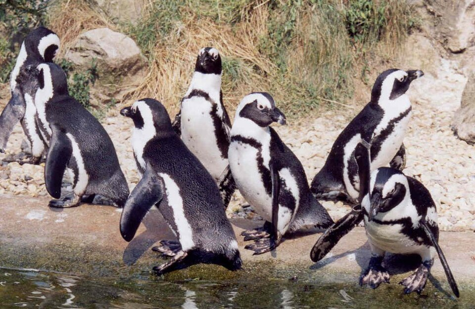

## Importing data

Vectors and other objects can be imported from existing files

```r
penguins_from_file <- readLines("penguins.txt")
head(penguins_from_file)
```

```
[1] "Fred"     "Betty"    "Brigitta" "Ulf"
```

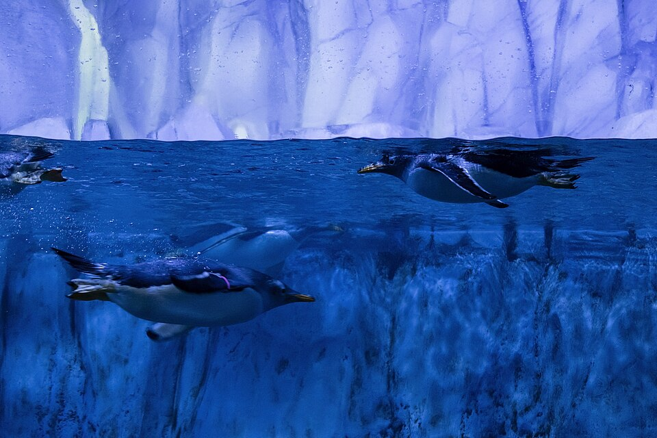

## We can do the same with dataframes

```r
penguins_data <- read.csv("penguins.csv")
dim(penguins_data)
```

```
[1] 344   8
```

```r
head(penguins_data)
```

```
  species    island bill_length_mm bill_depth_mm flipper_length_mm body_mass_g
1  Adelie Torgersen           39.1          18.7               181        3750
2  Adelie Torgersen           39.5          17.4               186        3800
3  Adelie Torgersen           40.3          18.0               195        3250
4  Adelie Torgersen             NA            NA                NA          NA
5  Adelie Torgersen           36.7          19.3               193        3450
6  Adelie Torgersen           39.3          20.6               190        3650
     sex year
1   male 2007
2 female 2007
3 female 2007
4   <NA> 2007
5 female 2007
6   male 2007
```

## The library command

It is used to load packages, which contain data or functions.

```r
library(palmerpenguins)

head(penguins)
```

```
# A tibble: 6 × 8
  species island    bill_length_mm bill_depth_mm flipper_length_mm body_mass_g
  <fct>   <fct>              <dbl>         <dbl>             <int>       <int>
1 Adelie  Torgersen           39.1          18.7               181        3750
2 Adelie  Torgersen           39.5          17.4               186        3800
3 Adelie  Torgersen           40.3          18                 195        3250
4 Adelie  Torgersen           NA            NA                  NA          NA
5 Adelie  Torgersen           36.7          19.3               193        3450
6 Adelie  Torgersen           39.3          20.6               190        3650
# ℹ 2 more variables: sex <fct>, year <int>
```

The packages must already be installed on your computer

```r
install.packages("newpackage")

library(newpackage)
```

## Install the following packages if you do not have them

```r
install.packages(tidyverse,
readxl,
writexl,
ggthemes,
broom,
palmerpenguins)
```

## Library() usually loads new functions

The most common use of “library()” is to load new functions.

For example, we will load two packages to import and export excel documents.

```r
library("readxl")
data <- read_excel("example_table.xlsx", sheet="Sheet1")
head(data)
```

```
# A tibble: 2 × 2
  example_column1 example_column_2
            <dbl> <chr>
1              53 Bruno
2              70 Giulia
```

```r
library("writexl")
write_xlsx(data, "Sheet1_example_table.xlsx")
```

## Import and export tables with tidyverse

Tidyverse import and export functions are quicker and, in my opinion, less prone to errors than base R ones

```r
library(tidyverse)
penguins_data <- read_csv("penguins.csv")
head(penguins_data)
```

```
# A tibble: 6 × 8
  species island    bill_length_mm bill_depth_mm flipper_length_mm body_mass_g
  <chr>   <chr>              <dbl>         <dbl>             <dbl>       <dbl>
1 Adelie  Torgersen           39.1          18.7               181        3750
2 Adelie  Torgersen           39.5          17.4               186        3800
3 Adelie  Torgersen           40.3          18                 195        3250
4 Adelie  Torgersen           NA            NA                  NA          NA
5 Adelie  Torgersen           36.7          19.3               193        3450
6 Adelie  Torgersen           39.3          20.6               190        3650
# ℹ 2 more variables: sex <chr>, year <dbl>
```

```r
write_tsv(penguins_data, "penguins.tsv")
```

A tidyverse dataframe is called a tibble. The most obvious difference is that they should not have rownames.

## Selecting columns with tidyverse

The “select” function is a quick way to choose specific columns of our dataframe

```r
select(penguins, species, island)
```

```
# A tibble: 344 × 2
   species island
   <fct>   <fct>
 1 Adelie  Torgersen
 2 Adelie  Torgersen
 3 Adelie  Torgersen
 4 Adelie  Torgersen
 5 Adelie  Torgersen
 6 Adelie  Torgersen
 7 Adelie  Torgersen
 8 Adelie  Torgersen
 9 Adelie  Torgersen
10 Adelie  Torgersen
# ℹ 334 more rows
```

## Removing columns with tidyverse

It can also be used to remove columns

```r
select(penguins, -species, -island)
```

```
# A tibble: 344 × 6
   bill_length_mm bill_depth_mm flipper_length_mm body_mass_g sex     year
            <dbl>         <dbl>             <int>       <int> <fct>  <int>
 1           39.1          18.7               181        3750 male    2007
 2           39.5          17.4               186        3800 female  2007
 3           40.3          18                 195        3250 female  2007
 4           NA            NA                  NA          NA <NA>    2007
 5           36.7          19.3               193        3450 female  2007
 6           39.3          20.6               190        3650 male    2007
 7           38.9          17.8               181        3625 female  2007
 8           39.2          19.6               195        4675 male    2007
 9           34.1          18.1               193        3475 <NA>    2007
10           42            20.2               190        4250 <NA>    2007
# ℹ 334 more rows
```

## Doing filtering with tidyverse

So to be fair selecting a column in a dataframe is not difficult, and you do not need tidyverse to do it:

```r
head(penguins$species, n = 2)
```

```
[1] Adelie Adelie
Levels: Adelie Chinstrap Gentoo
```

But tidyverse has many more useful functions!

```r
filter(penguins, species=='Adelie')
```

```
# A tibble: 152 × 8
   species island    bill_length_mm bill_depth_mm flipper_length_mm body_mass_g
   <fct>   <fct>              <dbl>         <dbl>             <int>       <int>
 1 Adelie  Torgersen           39.1          18.7               181        3750
 2 Adelie  Torgersen           39.5          17.4               186        3800
 3 Adelie  Torgersen           40.3          18                 195        3250
 4 Adelie  Torgersen           NA            NA                  NA          NA
 5 Adelie  Torgersen           36.7          19.3               193        3450
 6 Adelie  Torgersen           39.3          20.6               190        3650
 7 Adelie  Torgersen           38.9          17.8               181        3625
 8 Adelie  Torgersen           39.2          19.6               195        4675
 9 Adelie  Torgersen           34.1          18.1               193        3475
10 Adelie  Torgersen           42            20.2               190        4250
# ℹ 142 more rows
# ℹ 2 more variables: sex <fct>, year <int>
```

## Connecting commands in R

Many R and tidyverse commands are limited in scope, but you can combine them to perform complex tasks.

The “%>%” and “|>” operators are called “pipes”, and they take the output of a command and give it to the following one.

You print one of them with the shortcut “Ctrl+Shift+M”

```r
penguins %>% filter(species!='Adelie') %>%
  select(island) %>% dim()
```

```
[1] 192   1
```

## Create or modify columns with tidyverse

```r
penguins %>% mutate(New= bill_length_mm + 10) %>%
  select(New) %>% head()
```

```
# A tibble: 6 × 1
    New
  <dbl>
1  49.1
2  49.5
3  50.3
4  NA
5  46.7
6  49.3
```

## Creating new text columns

Mutate also works with text, if you combine it with the paste command:

```r
penguins %>% mutate(Descr= paste(species, island, 'cute', sep='_')) %>%
  select(Descr) %>% head(n=4)
```

```
# A tibble: 4 × 1
  Descr
  <chr>
1 Adelie_Torgersen_cute
2 Adelie_Torgersen_cute
3 Adelie_Torgersen_cute
4 Adelie_Torgersen_cute
```

## Dropping NAs

There are some NA value in our penguin dataset. There are several ways to deal with them:

- Dropping rows that have them
- Substituting NA values with the mean or median value of their column

As I am lazy we will just drop them:

```r
penguins <- penguins %>%  drop_na()
```

Notice that this is the first time I really modify the penguins dataset, as before I did not use “<-”

## Grouping

Sometimes you want to summarise data according to groups. Es: how many penguins per island per year

```r
summarised <- penguins %>%
  group_by(island, year, sex, species) %>%
  summarise(count = n())
head(summarised)
```

```
# A tibble: 6 × 5
# Groups:   island, year, sex [3]
  island  year sex    species count
  <fct>  <int> <fct>  <fct>   <int>
1 Biscoe  2007 female Adelie      5
2 Biscoe  2007 female Gentoo     16
3 Biscoe  2007 male   Adelie      5
4 Biscoe  2007 male   Gentoo     17
5 Biscoe  2008 female Adelie      9
6 Biscoe  2008 female Gentoo     22
```

## Grouping 2

It is a very flexible command and we cannot explore all functionalities.

```r
penguins %>%
  group_by(island, year, sex, species) %>%
  summarise(count = n(),
            bill_length_mm = max(bill_length_mm),
            body_mass_g = min(body_mass_g)) %>%
head()
```

```
# A tibble: 6 × 7
# Groups:   island, year, sex [3]
  island  year sex    species count bill_length_mm body_mass_g
  <fct>  <int> <fct>  <fct>   <int>          <dbl>       <int>
1 Biscoe  2007 female Adelie      5           40.5        3150
2 Biscoe  2007 female Gentoo     16           48.7        4150
3 Biscoe  2007 male   Adelie      5           40.6        3550
4 Biscoe  2007 male   Gentoo     17           59.6        5050
5 Biscoe  2008 female Adelie      9           39.6        2850
6 Biscoe  2008 female Gentoo     22           49.1        3950
```

## Pivot wider

Sometimes you want informations to be spread between more columns.

```r
wider <- summarised %>% pivot_wider(names_from=island, values_from= count)
head(wider)
```

```
# A tibble: 6 × 6
# Groups:   year, sex [3]
   year sex    species Biscoe Dream Torgersen
  <int> <fct>  <fct>    <int> <int>     <int>
1  2007 female Adelie       5     9         8
2  2007 female Gentoo      16    NA        NA
3  2007 male   Adelie       5    10         7
4  2007 male   Gentoo      17    NA        NA
5  2008 female Adelie       9     8         8
6  2008 female Gentoo      22    NA        NA
```

## Pivot longer

Sometimes you instead want to reduce the number of columns

```r
wider %>% pivot_longer(cols = c(Biscoe, Dream, Torgersen),
                       names_to = "island",
                       values_to = "count",
                       values_drop_na = TRUE)
```

```
# A tibble: 30 × 5
# Groups:   year, sex [6]
    year sex    species island    count
   <int> <fct>  <fct>   <chr>     <int>
 1  2007 female Adelie  Biscoe        5
 2  2007 female Adelie  Dream         9
 3  2007 female Adelie  Torgersen     8
 4  2007 female Gentoo  Biscoe       16
 5  2007 male   Adelie  Biscoe        5
 6  2007 male   Adelie  Dream        10
 7  2007 male   Adelie  Torgersen     7
 8  2007 male   Gentoo  Biscoe       17
 9  2008 female Adelie  Biscoe        9
10  2008 female Adelie  Dream         8
# ℹ 20 more rows
```

## Joining

It means to join two dataframes, based upon the value of a column

It is most used when you have a column showing individual IDs per observation.

```r
df <- penguins %>% mutate(ID =row_number()) %>% select(ID, everything())
head(df)
```

```
# A tibble: 6 × 9
     ID species island    bill_length_mm bill_depth_mm flipper_length_mm
  <int> <fct>   <fct>              <dbl>         <dbl>             <int>
1     1 Adelie  Torgersen           39.1          18.7               181
2     2 Adelie  Torgersen           39.5          17.4               186
3     3 Adelie  Torgersen           40.3          18                 195
4     4 Adelie  Torgersen           36.7          19.3               193
5     5 Adelie  Torgersen           39.3          20.6               190
6     6 Adelie  Torgersen           38.9          17.8               181
# ℹ 3 more variables: body_mass_g <int>, sex <fct>, year <int>
```

## Joining 2

The two dataframes should, of course, contain different data

```r
df1 <- df %>% filter(year==2007) %>% select(ID, species)
df2 <- df %>% filter(species=="Gentoo") %>% select(ID, island)

df1 %>% inner_join(df2, by="ID") %>% head()
```

```
# A tibble: 6 × 3
     ID species island
  <int> <fct>   <fct>
1   147 Gentoo  Biscoe
2   148 Gentoo  Biscoe
3   149 Gentoo  Biscoe
4   150 Gentoo  Biscoe
5   151 Gentoo  Biscoe
6   152 Gentoo  Biscoe
```

## Joining 3

You can use left, right, full and inner join to get different datasets

```r
# penguins present in df1 but not necessarily in df2
df1 %>% left_join(df2, by="ID") %>% head(n=2)
```

```
# A tibble: 2 × 3
     ID species island
  <int> <fct>   <fct>
1     1 Adelie  <NA>
2     2 Adelie  <NA>
```

```r
# penguins present in df2 but not necessarily in df1
df1 %>% right_join(df2, by="ID") %>% head(n=2)
```

```
# A tibble: 2 × 3
     ID species island
  <int> <fct>   <fct>
1   147 Gentoo  Biscoe
2   148 Gentoo  Biscoe
```

## Joining 4

You can use left, right, full and inner join to get different datasets

```r
# penguins present in both df1 and df2
df1 %>% inner_join(df2, by="ID") %>% head(n=2)
```

```
# A tibble: 2 × 3
     ID species island
  <int> <fct>   <fct>
1   147 Gentoo  Biscoe
2   148 Gentoo  Biscoe
```

```r
# penguins not necessarily present in df1 or df2
df1 %>% full_join(df2, by="ID") %>% head(n=2)
```

```
# A tibble: 2 × 3
     ID species island
  <int> <fct>   <fct>
1     1 Adelie  <NA>
2     2 Adelie  <NA>
```

## How to make new functions?

In R ( and many other languages), you can make new functions by combining existing ones.

```r
remove_na_and_show <- function(df, x) {
  # Remove rows with NA values
  cleaned_df <- drop_na(df)

  # Show the first x rows
  head(cleaned_df, x)
}

remove_na_and_show(penguins, 2)
```

```
# A tibble: 2 × 8
  species island    bill_length_mm bill_depth_mm flipper_length_mm body_mass_g
  <fct>   <fct>              <dbl>         <dbl>             <int>       <int>
1 Adelie  Torgersen           39.1          18.7               181        3750
2 Adelie  Torgersen           39.5          17.4               186        3800
# ℹ 2 more variables: sex <fct>, year <int>
```

## Small tip on using AI to solve problems 1

AIs are very powerful tools, but they can also give wrong results if you are having an unusual problem or **if you express it in an unusual way**.

To make sure the AI understands what you want, try to define your problem, give examples, and explain carefully what you want.

For example, “I want to get the highest value in column body_mass” is not a good question, as the AI will not know which coding language you are using and how the data is organised.

## Small tip on using AI to solve problems 2

If you can attach your dataframe, or a subsection of it, to the chat with the LLM, and you specify which coding language it has to use, as well as the objective of the analysis, you will normally have good results.

However, LLMs can give wrong answers if your question is very specific (ex: specific option of specific package). In that case it is better to check directly the manual of the package.

## Example of good question:

I have an R dataframe, and I want to extract the row with the highest value in column “flipper_length_mm”, among the rows that have “male” as value in the ” sex” column. Use tidyverse commands if possible.

## Never use code you do not understand!

Always look up the manual of the functions that AI suggests, unless you really understand the answer.

You can also ask the AI to explain what the code does, piece by piece. It is sufficient to ask “can you explain what the previous code does, one command at a time?”

Remember: you are ultimately responsible for whatever you run!

## Exercises:

- How much does the heaviest penguin weight? Which species is it and what island does it come from?
- How many penguins are females?
- How many penguins of the Gentoo species are males?
- Which penguin species is most frequent on the Biscoe island?
- Group the penguins according to island, sex and species. Show the number of penguins for each combination of these traits.

## More exercises:

- Using the grouped summary, use pivot_wider to expand the species column in three columns. Export the resulting tibble to a file in any format.
- Import the tibble you just exported, and use pivot_longer obtain again a single column with all the species information.
- From the penguins_raw dataset, extract a 2 column tibble with Individual IDs and Island. Keep only individuals from the Dream island and then left_join this dataset with penguins_raw. What happens to the Island column when you do this?

## In case of problems remember to:

- Download this presentation and reread the slides from here: https://github.com/UPSCb/Intro_to_R
- Google error messages
- Use AI models (carefully, try to understand everything the AI model is telling you)
- Ask the teachers
- Use the cheatsheet (https://rstudio.github.io/cheatsheets/html/data-transformation.html)

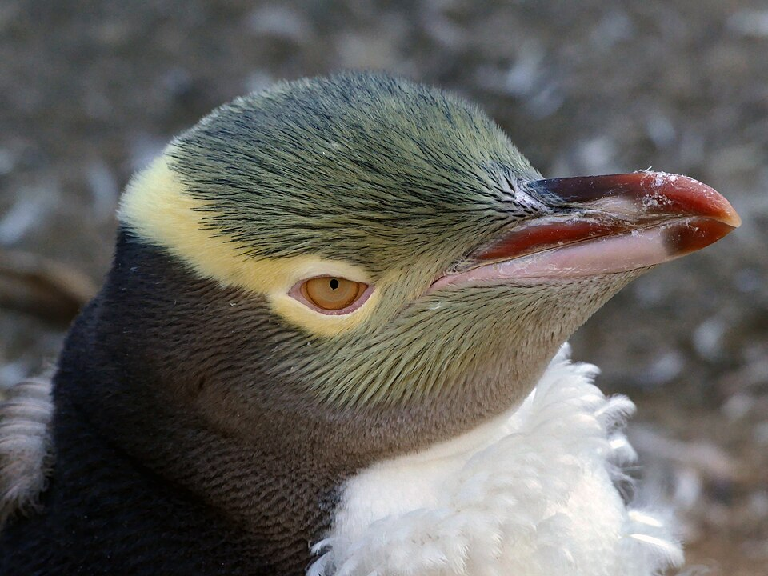